# IODS course project

Meri Korhonen

# Introduction to Open Data Science - Course Project

# About the project

*Write a short description about the course and add a link to your GitHub repository here. This is an R Markdown (.Rmd) file so you should use R Markdown syntax.*

First day of the course. I expect to learn about version control and programming with R.

https://github.com/merikorho/IODS-project

```r
# This is a so-called "R chunk" where you can write R code.

date()
```

```
## [1] "Sun Dec 12 21:37:32 2021"
```

The text continues here.

# Assignment 2: Linear regression

```
# Meri Korhonen 9.11.2021
# Script to fit linear regression model

# read the data set and check the structure
df = read.csv("data/learning2014.csv")
str(df)

# access the GGally and ggplot2 libraries
library(GGally)
library(ggplot2)

# create a summary plot matrix of all variables with ggpairs()
#ggpairs(df[-1], lower = list(combo = wrap("facethist", bins = 20)))
# create a more advanced plot matrix with ggpairs()
ggpairs(df[-1], mapping = aes(col = gender, alpha = 0.3), lower = list(combo = wrap("facethist", bins = 20)))

# --- PLOT SCATTER PLOTS WITH LINEAR REGRESSION (plots not included in the final analysis)

# initialize plot with data and aesthetic mapping
p1 <- ggplot(df, aes(x = stra, y = Points, col = gender))
# define the visualization type (points)
p2 <- p1 + geom_point()
# add a regression line
p3 <- p2 + geom_smooth(method = "lm")
# add a main title and draw the plot
p4 <- p3 + ggtitle("Student's strategic approach versus exam points")
# draw the plot
p4

# another scatter plot (no gender distinction) of points versus attitude
qplot(attitude, Points, data = df) + geom_smooth(method = "lm")

# --- FIT LINEAR MODEL

# create a regression model with multiple explanatory variables
my_model <- lm(Points ~ attitude + stra + surf, data = df)
# print out a summary of the model
summary(my_model)

# see the results of the model with only attitude as explanatory variable
my_model2 <- lm(Points ~ attitude, data = df)
summary(my_model2)

# draw diagnostic plots using the plot() function. Choose the plots 1, 2 and 5
par(mfrow = c(2,2))
plot(my_model2, which = c(1,2,5))
```

**Introducing the data set**

The analyzed data consists of seven variables associated with people’s learning habits. Collected background information includes a person’s gender and age. Learning habits were measured by verbal questions and measured with a scale from 0 to 5. The variables associated with learning are attitude as well as deep, strategic and surface learning skills. The learning outcome is measured as exam points. In total, learning processes of 166 persons were studied.

Figure 1 shows summary of the relationships and distributions of all studied variables. Of the studied persons majority are female (red) and around one third male (blue). In general the variables are nearly normally distributed, although some tails exist especially in data describing males. This may be due to the smaller group size, which allows the peripheral values to influence the distribution. The distribution in age is close to lognormal with most persons belonging to the age group 19-21.

Here the focus is on exam points as it is a concrete outcome of the learning strategies of the studied persons. From the last column in Figure 1 it can be seen that the difference between genders are generally low and, also due to the rather low group size, in this analysis no gender distinction will be made. The highest correlation with exam points occurs with attitude (r²~0.44). Lower correlations occur with strategic learning skills (r²~0.15) and surface learning skills (r²~-0.14). These three variables will be studied further.

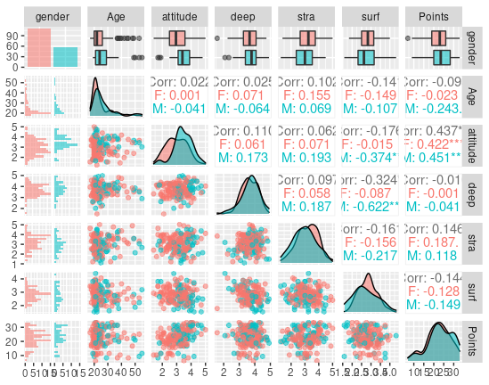

Figure 1. Summary of all variables in the study.

**Modeling the data**

Multiple linear regression model is fitted to the data in order to see whether exam points can be predicted by persons’ attitude, strategic and surface learning skills. The results are summarized in Table 1. The multiple R-squared of the fit is 0.21, indicating that 21 % of the variety in exam points can be attributed to these variables.

Of the three explanatory variables only attitude has P-value close to zero, indicating statistically significant correlation with exam points. According to the P-value, strategic and surface learning skills have no significant influence on success in exam. To confirm this, it is necessary to look at the standardized regression coefficients. They are 0.42, 0.11 and -0.05 for attitude, strategic and surface learning skills, respectively. It is seen that the standardized regression coefficients for attitude and strategic learning skills have the same order of magnitude. Therefore the strategic learning skills could potentially have importance for success in exam. However, as attitude is still clearly the most important predictor, both strategic and surface learning skills will be excluded from further analysis and I will only focus on attitude.

Table 1. Summary of results from fitting multiple linear regression model to exam points with attitude, strategic and surface learning skills as explanatory variables. (Residual standard error = 5.296, DF = 162, Multiple R-squared = 0.2074, Adjusted R-squared = 0.1927, F-statistic = 14.13, p-value = 3.156e-08)

|  | Estimate | Std. Error | T value | Pr(>\|t\|) |
| --- | --- | --- | --- | --- |
| Intercept | 11.0171 | 3.6837 | 2.991 | 0.00322 ** |
| attitude | 3.3952 | 0.5741 | 5.913 | 1.93e-08 *** |
| strategic | 0.8531 | 0.5416 | 1.575 | 0.11716 |
| surface | -0.5861 | 0.8014 | -0.731 | 0.46563 |

In Table 2 the results of the linear regression fit with attitude as explanatory variable are summarized. Now the R-squared is 0.19, indicating that 19 % of the variety in exam points can be predicted with attitude. The adjusted R-squared is also 0.19, which is equal to the adjusted R-squared obtained with all three explanatory variables. Therefore it can be concluded that the strategic and surface learning skills do not increase, or increase only very slightly, the capability of the model to predict exam points.

Table 2. Summary of results from fitting linear regression model to exam points with attitude as explanatory variable. (Residual standard error = 5.32, DF = 164, Multiple R-squared = 0.1906, Adjusted R-squared = 0.1856, F-statistic = 38.61, p-value = 4.119e-09)

|  | Estimate | Std. error | T value | Pr(>\|t\|) |
| --- | --- | --- | --- | --- |
| Intercept | 11.6372 | 1.8303 | 6.358 | 1.95e-09 *** |
| attitude | 3.5255 | 0.5674 | 6.214 | 4.12e-09 *** |

**Diagnostics of the linear fit**

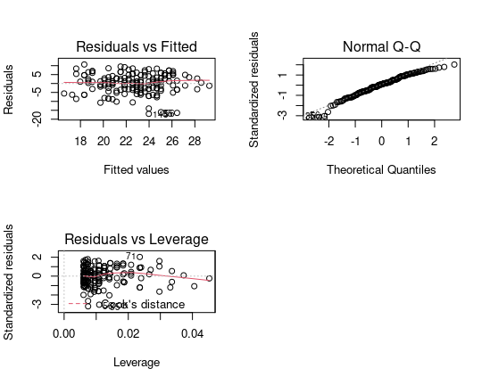

Figure 2. Diagnostics of the linear fit with attitude as explanatory variable.

# **Assignment 3: Logistic regression**

In this analysis the aim is to study students’ alcohol use. The study group consists of two Portuguese secondary level schools. The data includes background information such as age, gender and address as well as different variables describing family life and freetime. Alcohol use is presented as daily consumption on both weekdays and weekends on the scale from 1 to 5. Alcohol use is defined as high if the average daily consumption is over 2. The school performance is measured as grades in Portuguese language and mathematics (scale from 0 to 20) and here the average of the two grades is used. Together the study includes 370 students for whom all information (32 variables) is available.

```r
# read the data set and check the structure
alc = read.csv("data/alcohol_use.csv")
str(alc)
```

```
## 'data.frame':    370 obs. of  36 variables:
##  $ X         : int  1 2 3 4 5 6 7 8 9 10 ...
##  $ school    : chr  "GP" "GP" "GP" "GP" ...
##  $ sex       : chr  "F" "F" "F" "F" ...
##  $ age       : int  15 15 15 15 15 15 15 15 15 15 ...
##  $ address   : chr  "R" "R" "R" "R" ...
##  $ famsize   : chr  "GT3" "GT3" "GT3" "GT3" ...
##  $ Pstatus   : chr  "T" "T" "T" "T" ...
##  $ Medu      : int  1 1 2 2 3 3 3 2 3 3 ...
##  $ Fedu      : int  1 1 2 4 3 4 4 2 1 3 ...
##  $ Mjob      : chr  "at_home" "other" "at_home" "services" ...
##  $ Fjob      : chr  "other" "other" "other" "health" ...
##  $ reason    : chr  "home" "reputation" "reputation" "course" ...
##  $ guardian  : chr  "mother" "mother" "mother" "mother" ...
##  $ traveltime: int  2 1 1 1 2 1 2 2 2 1 ...
```

[output cut: 22 more lines]

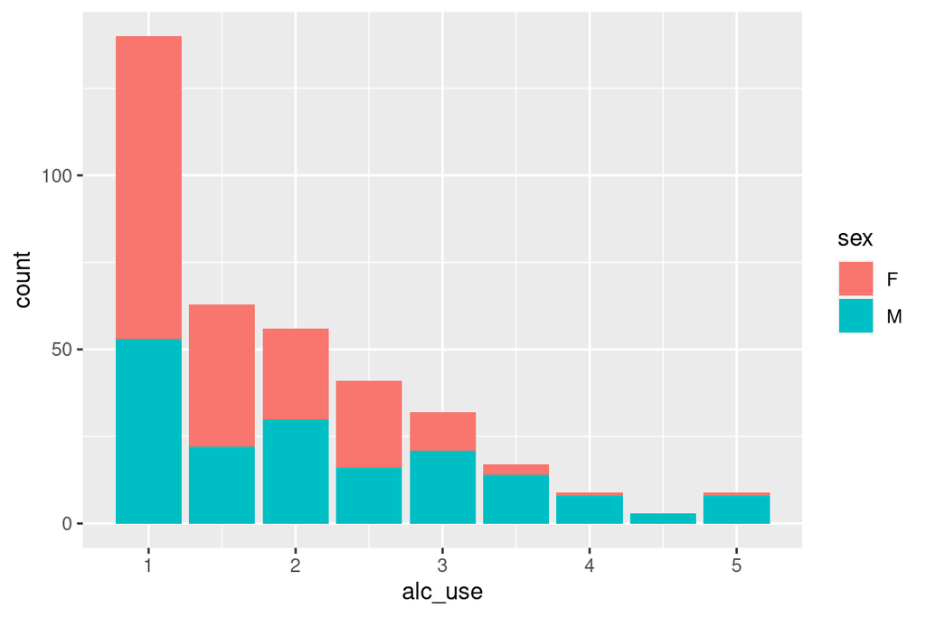

```r
# initialize a plot of alcohol use
g1 <- ggplot(data = alc, aes(x = alc_use, fill = sex))

# define the plot as a bar plot and draw it
g1 + geom_bar()
```

The figure above shows that the alcohol use in the study group is in general rather low. This is true especially for female students. This should be kept in mind when interpreting the results as the very few female students using lots of alcohol may influence the result considerably.

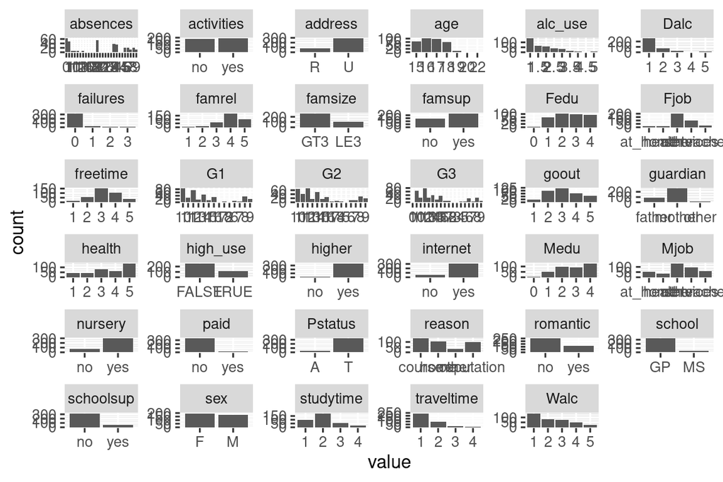

```r
# draw a bar plot of each variable
gather(alc[-1]) %>% ggplot(aes(value)) + facet_wrap("key", scales = "free") + geom_bar()
```

Initial hypothesis is that high alcohol use is related to frequent absences and lower grades. Previous class failures is assumed to have positive correlation with alcohol consumption. The quality of family relations is expected to be lower when alcohol consumption is high. It should be noted that to state whether these are causes or effects of high alcohol consumption is out of the scope of this analysis.

As seen in the figures below, the hypothesis of more frequent absences and lower grades with high alcohol consumption seems to be valid for male students. From the boxplot it is difficult to see whether or not the previous class failures are related to high alcohol use as the number of failures is so low in both groups. While the median value for family relations is rather good, 4, for both female and male students with or without high alcohol consumption, more students reported excellent (5) quality of family relations in the group with low alcohol consumption than in the group of high alcohol consumption indicating that the assumption is potentially valid. However, more thorough statistical analysis is needed to state the validity of these assumptions.

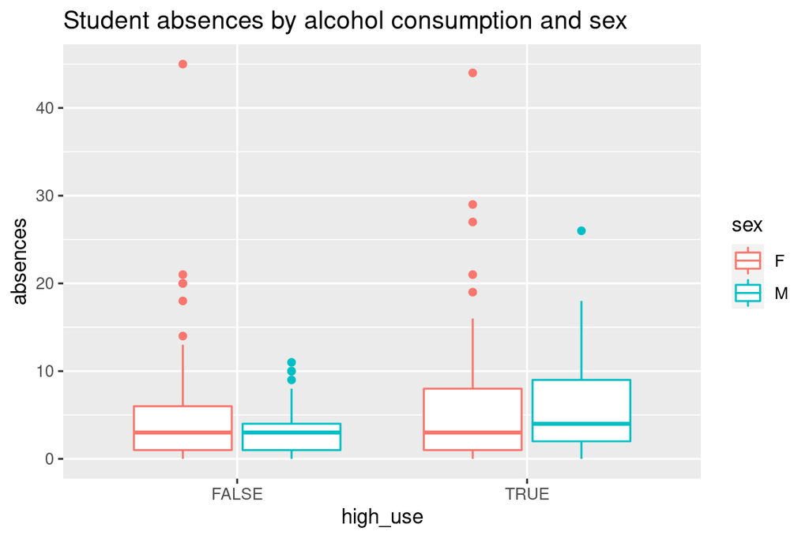

```r
# initialise a plot of high_use and absences
g1 <- ggplot(alc, aes(x = high_use, y = absences, col = sex))

# define the plot as a boxplot and draw it
g1 + geom_boxplot() + ylab("absences") + ggtitle("Student absences by alcohol consumption and sex")
```

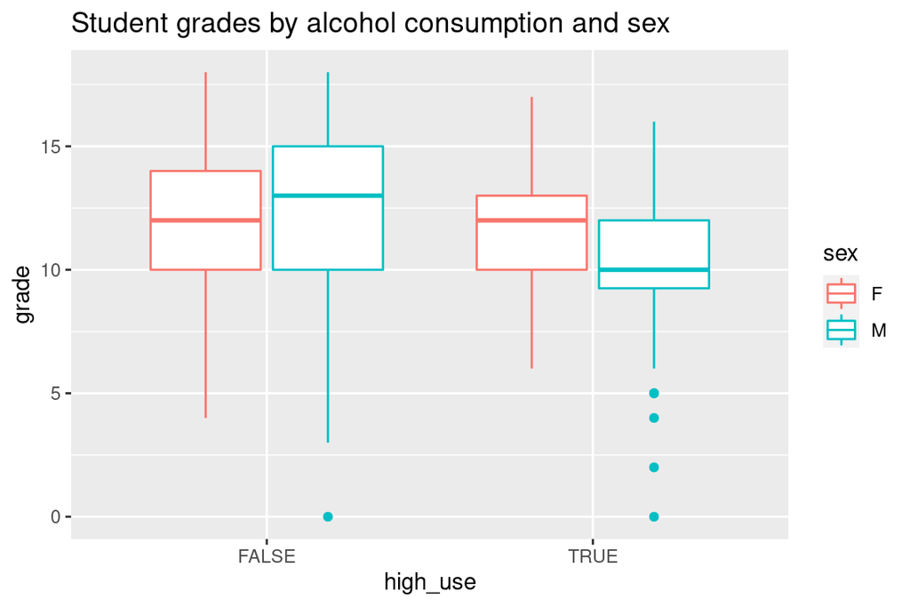

```r
# initialize a plot of high_use and grades
g2 <- ggplot(alc, aes(x = high_use, y = G3, col = sex))

# define the plot as a boxplot and draw it
g2 + geom_boxplot() + ylab("grade") + ggtitle("Student grades by alcohol consumption and sex")
```

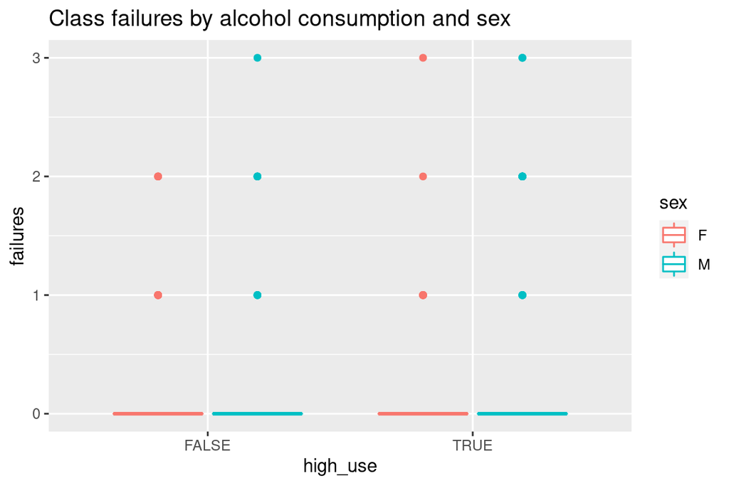

```r
# initialise a plot of high_use and failures
g3 <- ggplot(alc, aes(x = high_use, y = failures, col = sex))

# define the plot as a boxplot and draw it
g3 + geom_boxplot() + ylab("failures") + ggtitle("Class failures by alcohol consumption and sex")
```

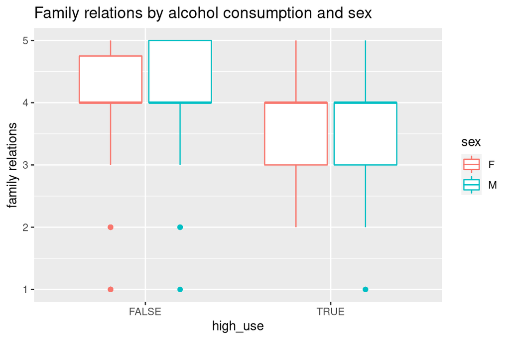

```r
# initialise a plot of high_use and family relations
g4 <- ggplot(alc, aes(x = high_use, y = famrel, col = sex))

# define the plot as a boxplot and draw it
g4 + geom_boxplot() + ylab("family relations") + ggtitle("Family relations by alcohol consumption and sex")
```

```r
# find logistic model with all four explanatory variables
m <- glm(high_use ~ absences + G3 + failures + famrel, data = alc, family = "binomial")

# print out a summary of the model
summary(m)
```

```
##
## Call:
## glm(formula = high_use ~ absences + G3 + failures + famrel, family = "binomial",
##     data = alc)
##
## Deviance Residuals:
##     Min       1Q   Median       3Q      Max
## -2.1684  -0.7891  -0.6692   1.1496   1.9954
##
## Coefficients:
##             Estimate Std. Error z value Pr(>|z|)
## (Intercept)  0.06039    0.69094   0.087 0.930348
## absences     0.07941    0.02265   3.506 0.000456 ***
## G3          -0.03900    0.03860  -1.010 0.312332
## failures     0.54397    0.21204   2.565 0.010306 *
## famrel      -0.24827    0.12704  -1.954 0.050682 .
## ---
## Signif. codes:  0 '***' 0.001 '**' 0.01 '*' 0.05 '.' 0.1 ' ' 1
##
## (Dispersion parameter for binomial family taken to be 1)
##
##     Null deviance: 452.04  on 369  degrees of freedom
## Residual deviance: 419.07  on 365  degrees of freedom
## AIC: 429.07
##
## Number of Fisher Scoring iterations: 4
```

To further analyse the significance of the variables, the odds ratios and their confidence intervals are calculated (shown below). The confidence intervals for the odds ratios of grades and family relations include value 1. Therefore it can be concluded that there is no significant association between grades or family relations and high alcohol consumption. The confidence intervals for the odds ratios of absences and failures are above 1 and therefore both frequent absences and previous class failurescan be considered to increase the probability of high alcohol consumption. This supports the initial hypothesis.

Although grades and family relations are not found as significant predictors, the fact that their odds ratios are below 1 supports the hypothesis that grades and quality of family relations decrease with high alcohol consumption.

```r
# compute odds ratios (OR)
OR <- coef(m) %>% exp

# compute confidence intervals (CI)
CI <- confint(m) %>% exp
# print out the odds ratios with their confidence intervals
cbind(OR, CI)
```

```
##                    OR     2.5 %   97.5 %
## (Intercept) 1.0622535 0.2716427 4.119475
## absences    1.0826492 1.0378918 1.134607
## G3          0.9617506 0.8914779 1.037582
## failures    1.7228263 1.1429817 2.644153
## famrel      0.7801522 0.6073480 1.001334
```

Since only absences and failures were found to have statistically significant relationship with high alcohol consumption, they are kept as the two explanatory variables in further analysis.

```r
# find the model with two most significant explanatory variables
m2 <- glm(high_use ~ absences + failures, data = alc, family = "binomial")

# print out a summary of the model
summary(m2)
```

```
##
## Call:
## glm(formula = high_use ~ absences + failures, family = "binomial",
##     data = alc)
##
## Deviance Residuals:
##     Min       1Q   Median       3Q      Max
## -2.2281  -0.7747  -0.6937   1.2043   1.7939
##
## Coefficients:
##             Estimate Std. Error z value Pr(>|z|)
## (Intercept) -1.38590    0.16717  -8.290  < 2e-16 ***
## absences     0.08402    0.02306   3.644 0.000269 ***
## failures     0.64059    0.20050   3.195 0.001398 **
## ---
## Signif. codes:  0 '***' 0.001 '**' 0.01 '*' 0.05 '.' 0.1 ' ' 1
##
## (Dispersion parameter for binomial family taken to be 1)
##
##     Null deviance: 452.04  on 369  degrees of freedom
## Residual deviance: 423.97  on 367  degrees of freedom
## AIC: 429.97
##
## Number of Fisher Scoring iterations: 4
```

Next it is tested how accurately the model with absences and failures as explanatory variables predicts high alcohol consumption. From the table and figure below, it is seen that in the observations around 70 % of the students reported low alcohol use while 30 % reported high alcohol use. For the prediction the same distribution is 92 % and 8 %. The model is therefore clearly missing an element predicting the risk of high alcohol consumption.

```r
# predict() the probability of high_use
probabilities <- predict(m2, type = "response")

# add the predicted probabilities to 'alc'
alc <- mutate(alc, probability = probabilities)

# use the probabilities to make a prediction of high_use
alc <- mutate(alc, prediction = probability > 0.5)

# tabulate the target variable versus the predictions
table(high_use = alc$high_use, prediction = alc$prediction) %>% prop.table() %>% addmargins()
```

```
##         prediction
## high_use      FALSE       TRUE        Sum
##    FALSE 0.66486486 0.03513514 0.70000000
##    TRUE  0.25135135 0.04864865 0.30000000
##    Sum   0.91621622 0.08378378 1.00000000
```

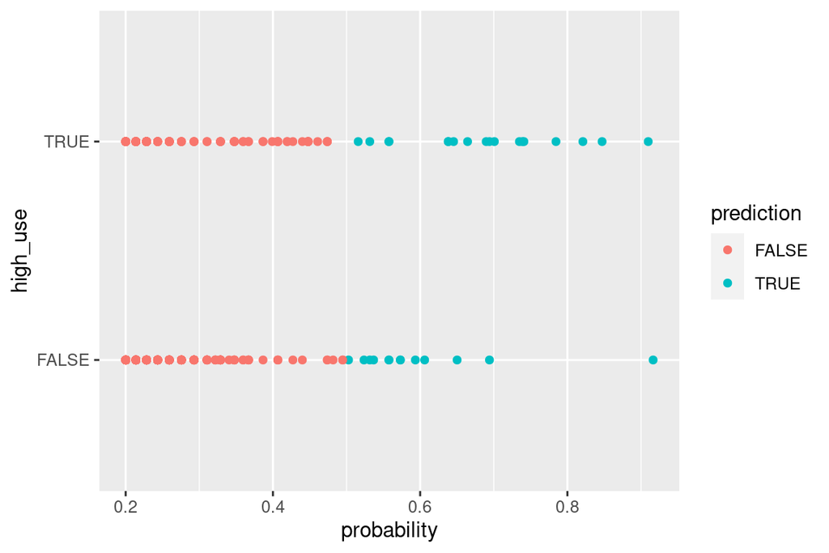

```r
# initialize a plot of 'high_use' versus 'probability' in 'alc'
g <- ggplot(alc, aes(x = probability, y = high_use, col = prediction))

# define the geom as points and draw the plot
g + geom_point()
```

The number of wrong predictions in the training data is 0.29 meaning that in 29 % of the cases the student’s alcohol consumption was could not be correctly predicted with the given variables (absences and failures). However, as clearly over 50 % of the cases could be correctly predicted with the model, it seems more plausible to use the model in predicting the student’s alcohol use than simple guessing strategy.

```r
# define a loss function (mean prediction error)
loss_func <- function(class, prob) {
  n_wrong <- abs(class - prob) > 0.5
  mean(n_wrong)
}

# compute the average number of wrong predictions in the training data
loss_func(class = alc$high_use, prob = alc$probability)
```

```
## [1] 0.2864865
```

Finally, I perform 10-fold cross-validation on the model. The results indicate that the test set performance is 0.30, which is larger than 0.26 obtained in the DataCamp model example. This means that the DataCamp model performance is better. In addition to absences and failures, the DataCamp model used gender as explanatory variable. As I noted in the beginning, the data shows very few female students with high alcohol consumption. Therefore, already based on the first figure, it should have been clear that being male increases the probability of high alcohol consumption. If I would refit the model, I would definitely include gender there as well.

```r
# K-fold cross-validation
library(boot)
cv <- cv.glm(data = alc, cost = loss_func, glmfit = m, K = 10)

# average number of wrong predictions in the cross validation
cv$delta[1]
```

```
## [1] 0.3054054
```

```r
date()
```

```
## [1] "Sun Dec 12 21:37:39 2021"
```

# **Assignment 4: Clustering and classification**

In this analysis I will use the Boston data set available at https://stat.ethz.ch/R-manual/R-devel/library/MASS/html/Boston.html. The data contains information on 14 variables describing the housing values in 506 suburbs of Boston. Here I will focus on the per capita crime rate (crim) and study if there is correspondence to any other variable. To conduct this analysis, different methods to cluster and classify the observations are tested.

```r
# load boston data and check contents
data("Boston")
summary(Boston)
```

```
##       crim                zn             indus            chas
##  Min.   : 0.00632   Min.   :  0.00   Min.   : 0.46   Min.   :0.00000
##  1st Qu.: 0.08205   1st Qu.:  0.00   1st Qu.: 5.19   1st Qu.:0.00000
##  Median : 0.25651   Median :  0.00   Median : 9.69   Median :0.00000
##  Mean   : 3.61352   Mean   : 11.36   Mean   :11.14   Mean   :0.06917
##  3rd Qu.: 3.67708   3rd Qu.: 12.50   3rd Qu.:18.10   3rd Qu.:0.00000
##  Max.   :88.97620   Max.   :100.00   Max.   :27.74   Max.   :1.00000
##       nox               rm             age              dis
##  Min.   :0.3850   Min.   :3.561   Min.   :  2.90   Min.   : 1.130
##  1st Qu.:0.4490   1st Qu.:5.886   1st Qu.: 45.02   1st Qu.: 2.100
##  Median :0.5380   Median :6.208   Median : 77.50   Median : 3.207
##  Mean   :0.5547   Mean   :6.285   Mean   : 68.57   Mean   : 3.795
##  3rd Qu.:0.6240   3rd Qu.:6.623   3rd Qu.: 94.08   3rd Qu.: 5.188
##  Max.   :0.8710   Max.   :8.780   Max.   :100.00   Max.   :12.127
##       rad              tax           ptratio          black
##  Min.   : 1.000   Min.   :187.0   Min.   :12.60   Min.   :  0.32
##  1st Qu.: 4.000   1st Qu.:279.0   1st Qu.:17.40   1st Qu.:375.38
##  Median : 5.000   Median :330.0   Median :19.05   Median :391.44
##  Mean   : 9.549   Mean   :408.2   Mean   :18.46   Mean   :356.67
##  3rd Qu.:24.000   3rd Qu.:666.0   3rd Qu.:20.20   3rd Qu.:396.23
##  Max.   :24.000   Max.   :711.0   Max.   :22.00   Max.   :396.90
##      lstat            medv
##  Min.   : 1.73   Min.   : 5.00
##  1st Qu.: 6.95   1st Qu.:17.02
##  Median :11.36   Median :21.20
##  Mean   :12.65   Mean   :22.53
##  3rd Qu.:16.95   3rd Qu.:25.00
##  Max.   :37.97   Max.   :50.00
```

Distributions and correlations of different variables are shown below. The distribution of crime rates resembles logarithmic distribution with mostly very low crime rates. The distributions of other variables are also skewed. This may cause problems when linear discriminate analysis and clustering is applied as one of the assumptions behind the method is normally distributed observations.

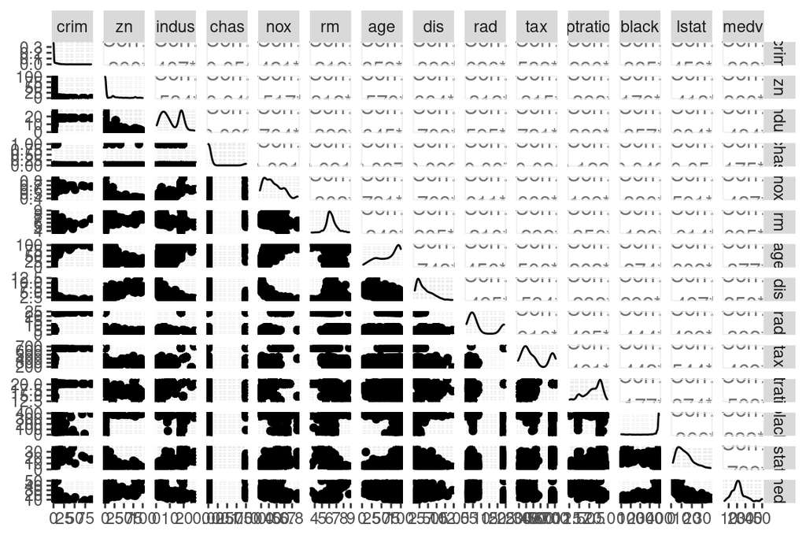

```r
ggpairs(Boston, lower = list(combo = wrap("facethist", bins = 20)))
```

Strong negative correlation is seen between weighted mean of distances to five Boston employment centres (dis) and proportion of owner-occupied units built prior to 1940 (age). With growing distance the proportion of old houses decreases, which is likely due to the fact that the old houses are concentrated near the center. Newer houses were build further away from the center as the city expanded. Distance is negatively correlated also with concentration of nitrogen oxides (nox), which means the pollution level decreases with growing distance from the city centers. Also the proportion of non-retail business acres per town (indus) decreases further away from the centers. These are really not relevant for the analysis conducted here, so I will not go deeper into the other variables but concentrate on the crime rate.

```r
# calculate the correlation matrix and round it
cor_matrix<-cor(Boston) %>% round(digits = 2)

# print the correlation matrix
cor_matrix
```

```
##          crim    zn indus  chas   nox    rm   age   dis   rad   tax ptratio
## crim     1.00 -0.20  0.41 -0.06  0.42 -0.22  0.35 -0.38  0.63  0.58    0.29
## zn      -0.20  1.00 -0.53 -0.04 -0.52  0.31 -0.57  0.66 -0.31 -0.31   -0.39
## indus    0.41 -0.53  1.00  0.06  0.76 -0.39  0.64 -0.71  0.60  0.72    0.38
## chas    -0.06 -0.04  0.06  1.00  0.09  0.09  0.09 -0.10 -0.01 -0.04   -0.12
## nox      0.42 -0.52  0.76  0.09  1.00 -0.30  0.73 -0.77  0.61  0.67    0.19
## rm      -0.22  0.31 -0.39  0.09 -0.30  1.00 -0.24  0.21 -0.21 -0.29   -0.36
## age      0.35 -0.57  0.64  0.09  0.73 -0.24  1.00 -0.75  0.46  0.51    0.26
## dis     -0.38  0.66 -0.71 -0.10 -0.77  0.21 -0.75  1.00 -0.49 -0.53   -0.23
## rad      0.63 -0.31  0.60 -0.01  0.61 -0.21  0.46 -0.49  1.00  0.91    0.46
## tax      0.58 -0.31  0.72 -0.04  0.67 -0.29  0.51 -0.53  0.91  1.00    0.46
## ptratio  0.29 -0.39  0.38 -0.12  0.19 -0.36  0.26 -0.23  0.46  0.46    1.00
## black   -0.39  0.18 -0.36  0.05 -0.38  0.13 -0.27  0.29 -0.44 -0.44   -0.18
## lstat    0.46 -0.41  0.60 -0.05  0.59 -0.61  0.60 -0.50  0.49  0.54    0.37
## medv    -0.39  0.36 -0.48  0.18 -0.43  0.70 -0.38  0.25 -0.38 -0.47   -0.51
##         black lstat  medv
## crim    -0.39  0.46 -0.39
## zn       0.18 -0.41  0.36
## indus   -0.36  0.60 -0.48
## chas     0.05 -0.05  0.18
## nox     -0.38  0.59 -0.43
## rm       0.13 -0.61  0.70
## age     -0.27  0.60 -0.38
## dis      0.29 -0.50  0.25
## rad     -0.44  0.49 -0.38
## tax     -0.44  0.54 -0.47
## ptratio -0.18  0.37 -0.51
## black    1.00 -0.37  0.33
## lstat   -0.37  1.00 -0.74
## medv     0.33 -0.74  1.00
```

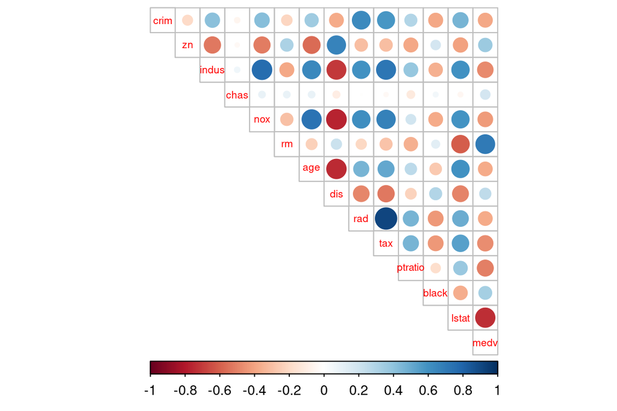

```r
# visualize the correlation matrix
corrplot(cor_matrix, method="circle", type="upper", cl.pos="b", tl.pos="d", tl.cex = 0.6)
```

First, the dataset is standardized in order to make the variables comparable when conducting classification. As seen from the summaries below, the standardized values are centered around zero. However, the scaling does not influence the original distribution and thus it can be seen from the histogram that the distribution of the scaled crime rate remains logarithmic.

```r
# center and standardize variables
boston_scaled <- scale(Boston)

# change the object to data frame
boston_scaled = as.data.frame(boston_scaled)

# summary of the scaled crime rate
summary(boston_scaled)
```

```
##       crim                 zn               indus              chas
##  Min.   :-0.419367   Min.   :-0.48724   Min.   :-1.5563   Min.   :-0.2723
##  1st Qu.:-0.410563   1st Qu.:-0.48724   1st Qu.:-0.8668   1st Qu.:-0.2723
##  Median :-0.390280   Median :-0.48724   Median :-0.2109   Median :-0.2723
##  Mean   : 0.000000   Mean   : 0.00000   Mean   : 0.0000   Mean   : 0.0000
##  3rd Qu.: 0.007389   3rd Qu.: 0.04872   3rd Qu.: 1.0150   3rd Qu.:-0.2723
##  Max.   : 9.924110   Max.   : 3.80047   Max.   : 2.4202   Max.   : 3.6648
##       nox                rm               age               dis
##  Min.   :-1.4644   Min.   :-3.8764   Min.   :-2.3331   Min.   :-1.2658
##  1st Qu.:-0.9121   1st Qu.:-0.5681   1st Qu.:-0.8366   1st Qu.:-0.8049
##  Median :-0.1441   Median :-0.1084   Median : 0.3171   Median :-0.2790
##  Mean   : 0.0000   Mean   : 0.0000   Mean   : 0.0000   Mean   : 0.0000
##  3rd Qu.: 0.5981   3rd Qu.: 0.4823   3rd Qu.: 0.9059   3rd Qu.: 0.6617
##  Max.   : 2.7296   Max.   : 3.5515   Max.   : 1.1164   Max.   : 3.9566
##       rad               tax             ptratio            black
##  Min.   :-0.9819   Min.   :-1.3127   Min.   :-2.7047   Min.   :-3.9033
##  1st Qu.:-0.6373   1st Qu.:-0.7668   1st Qu.:-0.4876   1st Qu.: 0.2049
##  Median :-0.5225   Median :-0.4642   Median : 0.2746   Median : 0.3808
##  Mean   : 0.0000   Mean   : 0.0000   Mean   : 0.0000   Mean   : 0.0000
##  3rd Qu.: 1.6596   3rd Qu.: 1.5294   3rd Qu.: 0.8058   3rd Qu.: 0.4332
##  Max.   : 1.6596   Max.   : 1.7964   Max.   : 1.6372   Max.   : 0.4406
##      lstat              medv
##  Min.   :-1.5296   Min.   :-1.9063
##  1st Qu.:-0.7986   1st Qu.:-0.5989
##  Median :-0.1811   Median :-0.1449
##  Mean   : 0.0000   Mean   : 0.0000
##  3rd Qu.: 0.6024   3rd Qu.: 0.2683
##  Max.   : 3.5453   Max.   : 2.9865
```

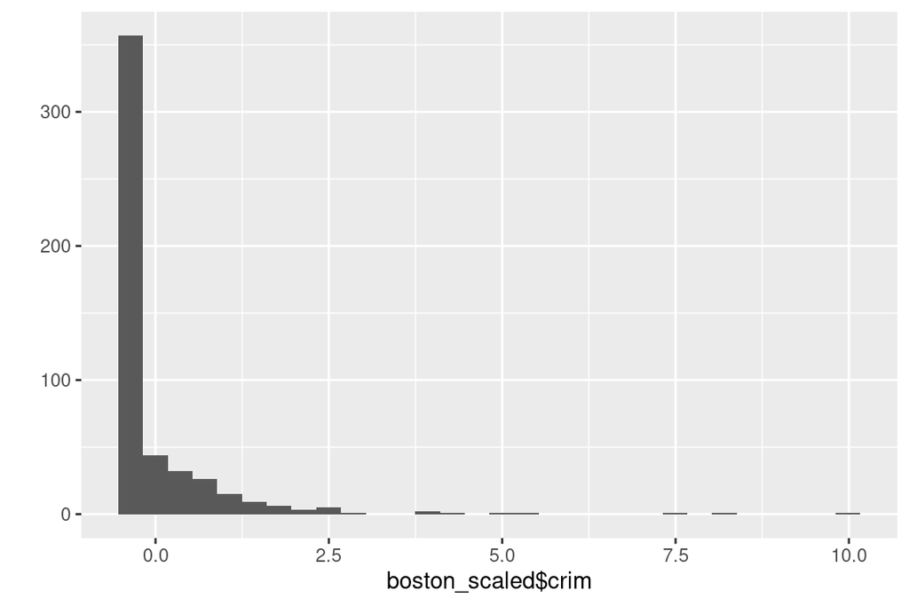

```r
# plot histogram to see the distribution of scaled crime rate
qplot(boston_scaled$crim, geom="histogram")
```

Next the scaled crime rate is categorized using quantiles as the break points. From the distribution it was already seen that most of the areas in Boston had very low crime rates, making the use of quantiles in categorizing the data questionable. Labeling the categories with equal amount of observations as low, med_low, med_high and high is thus a bit misleading as most of the suburbs have very low crime rate.

```r
# create a quantile vector of crim
bins <- quantile(boston_scaled$crim)

# create a categorical variable 'crime'
crime <- cut(boston_scaled$crim, breaks = bins, include.lowest = TRUE, labels = c("low", "med_low", "med_high", "high"))

# look at the table of the new factor crime
table(crime)
```

```
## crime
##      low  med_low med_high     high
##      127      126      126      127
```

```r
# remove original crim from the dataset
boston_scaled <- dplyr::select(boston_scaled, -crim)

# add the new categorical value to scaled data
boston_scaled <- data.frame(boston_scaled, crime)
```

Despite the distribution, I go on fitting linear discriminant analysis on the data. Before that the data is divided into train and test sets. The train set consists of 80 % of the observations.

```r
# number of rows in the Boston dataset
n <- nrow(boston_scaled)

# choose randomly 80% of the rows
ind <- sample(n,  size = n * 0.8)

# create train set
train <- boston_scaled[ind,]

# create test set
test <- boston_scaled[-ind,]

# save the correct classes from test data
correct_classes <- test$crim

# remove the crime variable from test data
test <- dplyr::select(test, -crime)
```

For data classification, the linear discriminant analysis is fitted on the train set with categorical crime rate as the target variable and all the other variables as predictor variables. The fit is shown in the figure below. As can be seen from the figure, the four categories (low, med_low, med_high, high) form two clusters. Of these categories med_high (green) is divided between these two clusters. Therefore, it seems that two categories could be enough to represent the data: low and high crime rates.

```r
# linear discriminant analysis
lda.fit <- lda(crime ~ ., data = train)

# print the lda.fit object
lda.fit
```

```
## Call:
## lda(crime ~ ., data = train)
##
## Prior probabilities of groups:
##       low   med_low  med_high      high
## 0.2599010 0.2227723 0.2648515 0.2524752
##
## Group means:
##                  zn      indus        chas        nox          rm        age
## low       0.9464896 -0.9174757 -0.12234430 -0.8749030  0.42582819 -0.8607858
## med_low  -0.1649470 -0.2329489 -0.05360128 -0.5247541 -0.17601011 -0.2997718
## med_high -0.3654210  0.2203978  0.16921488  0.3950047  0.09404253  0.4334717
## high     -0.4872402  1.0171096 -0.11793298  1.0399831 -0.45504529  0.8136923
##                 dis        rad        tax     ptratio       black         lstat
## low       0.8751393 -0.6909262 -0.7224579 -0.39517558  0.37932418 -0.7683286693
## med_low   0.3226436 -0.5620427 -0.4649384  0.04004194  0.31102847 -0.0952483536
## med_high -0.3866561 -0.4441310 -0.3190387 -0.31660849  0.07497311  0.0009321282
## high     -0.8416319  1.6382099  1.5141140  0.78087177 -0.73979756  0.9458108729
##                 medv
## low       0.49814369
## med_low  -0.02845409
## med_high  0.19295969
## high     -0.76862029
##
## Coefficients of linear discriminants:
##                 LD1         LD2         LD3
## zn       0.08510379  0.72855222 -0.95000568
## indus    0.05041011 -0.38214943  0.26105040
## chas    -0.05261154 -0.02407492  0.03796483
## nox      0.42111069 -0.69905714 -1.25374130
## rm       0.01885317 -0.01069764 -0.18701540
## age      0.21127072 -0.36675675 -0.18600984
## dis     -0.03233969 -0.36460615  0.22808453
## rad      3.41303333  0.79195704 -0.05024993
## tax     -0.01683871  0.11920772  0.41031238
## ptratio  0.12688564  0.02808240 -0.17745126
## black   -0.08590746  0.04015939  0.11080368
## lstat    0.17832068 -0.22507330  0.47558606
## medv     0.06926987 -0.49350551 -0.09016951
##
## Proportion of trace:
##    LD1    LD2    LD3
## 0.9505 0.0380 0.0115
```

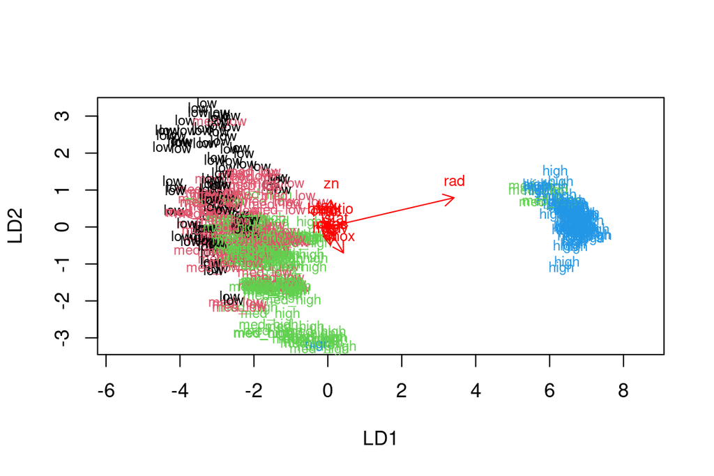

```r
# the function for lda biplot arrows
lda.arrows <- function(x, myscale = 1, arrow_heads = 0.1, color = "red", tex = 0.75, choices = c(1,2)){
  heads <- coef(x)
  arrows(x0 = 0, y0 = 0,
         x1 = myscale * heads[,choices[1]],
         y1 = myscale * heads[,choices[2]], col=color, length = arrow_heads)
  text(myscale * heads[,choices], labels = row.names(heads),
       cex = tex, col=color, pos=3)
}

# target classes as numeric
classes <- as.numeric(train$crime)

# plot the lda results
plot(lda.fit, dimen = 2, col = classes, pch = classes)
lda.arrows(lda.fit, myscale = 1)
```

The linear discriminant analysis model fitted to the train dataset is used to predict the classes of the test data. The results are shown in the table below with comparison to the correct categories. It is seen that the majority of the results lie on the diagonal, meaning that the prediction matches the original categories rather well. There are no predictions that are completely off as the values in the bottom left and top right corners are zeros. Although the model seems to perform reasonably well, there are some discrepancies.

```r
# predict classes with test data
lda.pred <- predict(lda.fit, newdata = test)

# cross tabulate the results
table(correct = correct_classes, predicted = lda.pred$class)
```

```
##           predicted
## correct    low med_low med_high high
##   low       12       9        1    0
##   med_low   10      19        7    0
##   med_high   0       7       10    2
##   high       0       0        0   25
```

Because the linear discriminant analysis showed that perhaps only two categories are needed, Euklidean distance is calculated to represent similarities between observations and K-means clustering is applied to investigate the optimal number of categories. From the figure below it is seen that as the curve decreases strongly around value 2, two categories are sufficient to represent the similarities within the data.

```r
# reload the Boston dataset
data("Boston")

# center and standardize variables
boston_scaled <- scale(Boston)

# change the object to data frame
boston_scaled = as.data.frame(boston_scaled)

# euclidean distance matrix
dist_eu <- dist(boston_scaled)

# look at the summary of the distances
summary(dist_eu)
```

```
##    Min. 1st Qu.  Median    Mean 3rd Qu.    Max.
##  0.1343  3.4625  4.8241  4.9111  6.1863 14.3970
```

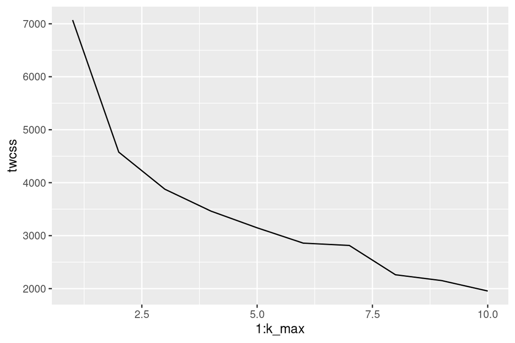

```r
# k-means clustering
km <-kmeans(boston_scaled, centers = 3)

set.seed(123)

# determine the number of clusters
k_max <- 10

# calculate the total within sum of squares
twcss <- sapply(1:k_max, function(k){kmeans(boston_scaled, k)$tot.withinss})

# visualize the results
qplot(x = 1:k_max, y = twcss, geom = 'line')
```

As two categories seems to be sufficient to represent the data, the K-means clustering is applied again with two centers. From the figure below it is seen that the centers of the two groups are clearly separated for many of the variables. In the uppermost row red dots represents the group of low crime rate and black dots the group of high crime rate. As many of the variables are beyond my understanding, it is difficult for me to make conclusions of the results. However, for example, crime rate versus proportion of lower status population (lstat) is higher in the areas with high crime rate. Also the median value of owner occupied houses (medv) is lower in the high crime areas. Crime rate seems also in general higher when the distance from centers is low. On the other hand, the proportion of blacks in town does not seem to clearly influence the crime rate (although, this value is originally scaled as 1000(Bk - 0.63)^2 where Bk is the proportion of blacks, and therefore it is not so easy to understand what is going on here).

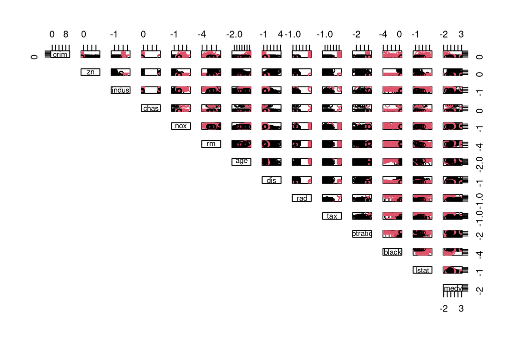

```r
# k-means clustering
km <-kmeans(boston_scaled, centers = 2)

# plot the Boston dataset with clusters
pairs(boston_scaled, col = km$cluster, lower.panel = NULL)
```

Grouping with two centers (above) can be compared to grouping with three centers shown below. With three groups there are some overlapping with centers.

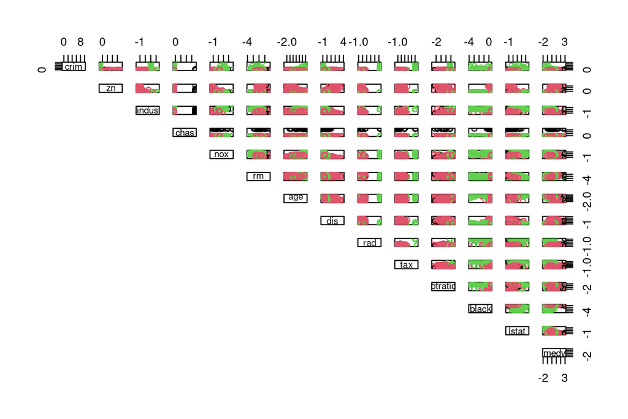

```r
# k-means clustering
km <-kmeans(boston_scaled, centers = 3)

# plot the Boston dataset with clusters
pairs(boston_scaled, col = km$cluster, lower.panel = NULL)
```

```r
date()
```

```
## [1] "Sun Dec 12 21:38:01 2021"
```

# **Assignment 5: Dimensionality Reduction Techniques**

Here a dataset of parameters describing living conditions in different countries is studied. The variables include maternal mortality (Mat.Mor), life expectancy (Life.Exp), expected years of education (Edu.Exp) adolescent birth rate (ado.Birth), gross national income (GNI), ratio of labor force participation of females and males (Labo.FM), ratio of female and male populations with secondary education (Edu2.FM) and ratio of female representatives in parliament (Parli.F). Below a summay of the variables is shown. More information can be found from http://hdr.undp.org/en/content/human-development-index-hdi.

```r
# read the data set and check the structure
human = read.csv("data/human.csv")
summary(human)
```

```
##    Country             Edu2.FM          Labo.FM          Life.Exp
##  Length:155         Min.   :0.1717   Min.   :0.1857   Min.   :49.00
##  Class :character   1st Qu.:0.7264   1st Qu.:0.5984   1st Qu.:66.30
##  Mode  :character   Median :0.9375   Median :0.7535   Median :74.20
##                     Mean   :0.8529   Mean   :0.7074   Mean   :71.65
##                     3rd Qu.:0.9968   3rd Qu.:0.8535   3rd Qu.:77.25
##                     Max.   :1.4967   Max.   :1.0380   Max.   :83.50
##     Edu.Exp           GNI            Mat.Mor         Ado.Birth
##  Min.   : 5.40   Min.   :   581   Min.   :   1.0   Min.   :  0.60
##  1st Qu.:11.25   1st Qu.:  4198   1st Qu.:  11.5   1st Qu.: 12.65
##  Median :13.50   Median : 12040   Median :  49.0   Median : 33.60
##  Mean   :13.18   Mean   : 17628   Mean   : 149.1   Mean   : 47.16
##  3rd Qu.:15.20   3rd Qu.: 24512   3rd Qu.: 190.0   3rd Qu.: 71.95
##  Max.   :20.20   Max.   :123124   Max.   :1100.0   Max.   :204.80
##     Parli.F
##  Min.   : 0.00
##  1st Qu.:12.40
##  Median :19.30
##  Mean   :20.91
##  3rd Qu.:27.95
##  Max.   :57.50
```

As can be seen from the figure below, many of the variables are skewed. The skewedness is negative for F/M -ratio in secondary education and labor force as well as life expectancy. This means that although in many countries the ratios and life expectancy are rather high, the mean is lowered by a few countries having very low ratios or life expectancy. The skewedness is also quite natural as both, the ratio and life expectancy have a rather set upper limit that cannot be exceeded. The distribution of female representatives in parliament is positively skewed, meaning that it is more typical for countries to have parliament where majority of representatives are men and the parliaments with female majority are rarities. Gross national income, maternal mortality and adolescent birth rate have strong positively skewed distributions. Expected years of education has the only nearly normal distribution.

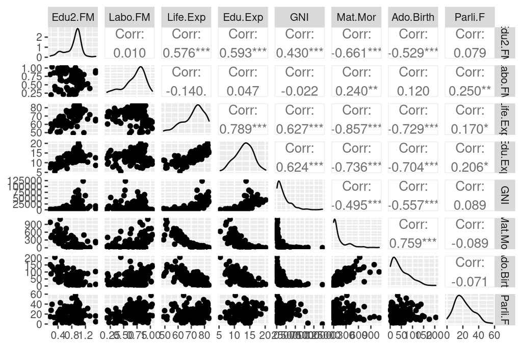

```r
# visualize the data
ggpairs(human[-1], lower = list(combo = wrap("facethist", bins = 20)))
```

The correlations between variables are better seen in the correlation matrix below. Education and gross national income seem to increase life expectancy. In the countries where maternal mortality and adolescent birth rate are high, the life expectancy is lower. These two also correlate positively, meaning that where adolescent birth rate is high, also maternal mortality is more common. High adolescent birth rates and maternal mortality seems to also go together with low education and gross national income. Quite interestingly, the ration in labor force and parliament do not seem to correlate strongly with any of the other variables.

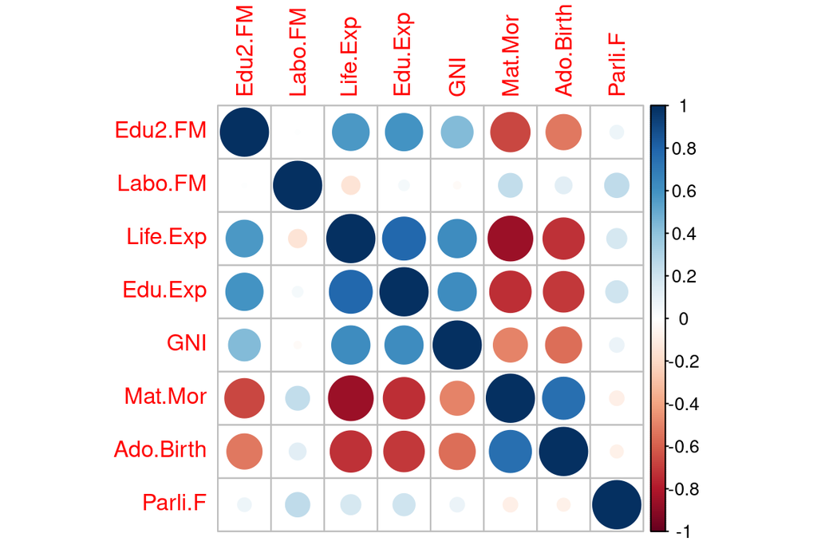

```r
# compute the correlation matrix and visualize it with corrplot
cor(human[-1]) %>% corrplot
```

As seen from the correlation matrix, some of the variables are highly correlated. Therefore it could be useful to perform Principal Component Analysis in order to reduce the dimensions of the dataset and find the linear combination(s) accounting for most of the variation in the data. First PCA is performed on the non-standardized dataset. It is already seen in the warning messages when plotting that there is a large difference in the variances of the variables. Non-standardized dataset where variables have very different scales and magnitudes lead typically to dominance of one variable with the largest variance. This is the case also here: the gross national income domianates the scaling of the figure, leaving the arrows representing other variables with length zero and therefore they are not plotted.

```r
# perform principal component analysis (with the SVD method)
pca_human <- prcomp(human[-1])

# create a summary of pca_human
s <- summary(pca_human)

# rounded percentages of variance captured by each PC
pca_pr <- round(100*s$importance[2,], digits = 1)

# print out the percentages of variance
pca_pr
```

```
## PC1 PC2 PC3 PC4 PC5 PC6 PC7 PC8
## 100   0   0   0   0   0   0   0
```

[output not shown]

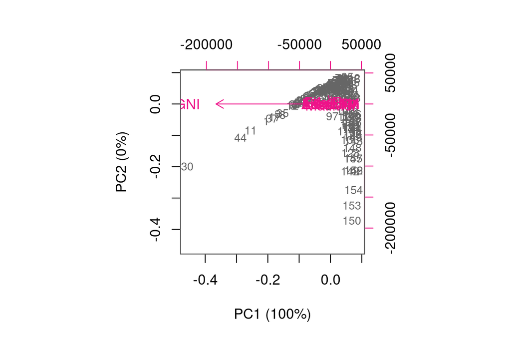

```r
# create object pc_lab to be used as axis labels
pc_lab <- paste0(names(pca_pr), " (", pca_pr, "%)")

# draw a biplot
biplot(pca_human, cex = c(0.8, 1), col = c("grey40", "deeppink2"), xlab = pc_lab[1], ylab = pc_lab[2])
```

It is wiser to do the PCA with standardized data and now the visualization is nicely centered around zero as seen in the figure below. The pink arrows representing the original variables show same correlations as already seen in the correlation matrix: life expectancy is correlated with education and gross national income (small angle between the arrows). They also correlate negatively with maternal mortality and adolescent birth rate (angle of 180 degrees). These arrows are nearly parallel to the PC1 axis, meaning that they do not considerably contribute to PC2. In contrast, female representatives in parliament and labor force ratio contribute mostly to PC2 and not considerably to PC1. The slight tilt in the Parli.F -arrow could, however, indicate that the ratio of females in parliament is likely to be higher in countries with higher education, higher gross national income and higher life expectancy.

The summary of the components (below) shows that the first PC explains roughly half (54 %) of the variance. The second PC explains an additional 16 %. In order to explain over 90 % of the variance, in total five components are needed, but 70 % explained by the two first components can also be regarded as sufficient. Visualizing PC1 and PC2 on a biplot (below), some clustering is revealed, although the groups are not very tight. Dots labeled with small numbers, representing industrialized countries such as most European countries, are concentrated to the negative (left) side of the x-axis (PC1) whereas larger numbers, representing less developed, for example many African countries, are to the positive (right) side. The PC1 can thus be seen to represent life expectancy and the variables correlated with it. PC2 does not contribute to the life expectancy but increases the spread along the y-axis.

Although it was nice to learn about Principal Component Analysis, it mainly confirms what is already seen from the correlation matrix. However, I can see its usefulness in analyzing multivariate datasets.

```r
# standardize the variables
human_std <- scale(human[-1])

# perform principal component analysis (with the SVD method)
pca_human_std <- prcomp(human_std)

# create a summary of pca_human_std
s <- summary(pca_human_std)

# rounded percentages of variance captured by each PC
pca_pr <- round(100*s$importance[2,], digits = 1)

# print out the percentages of variance
pca_pr
```

```
##  PC1  PC2  PC3  PC4  PC5  PC6  PC7  PC8
## 53.6 16.2  9.6  7.6  5.5  3.6  2.6  1.3
```

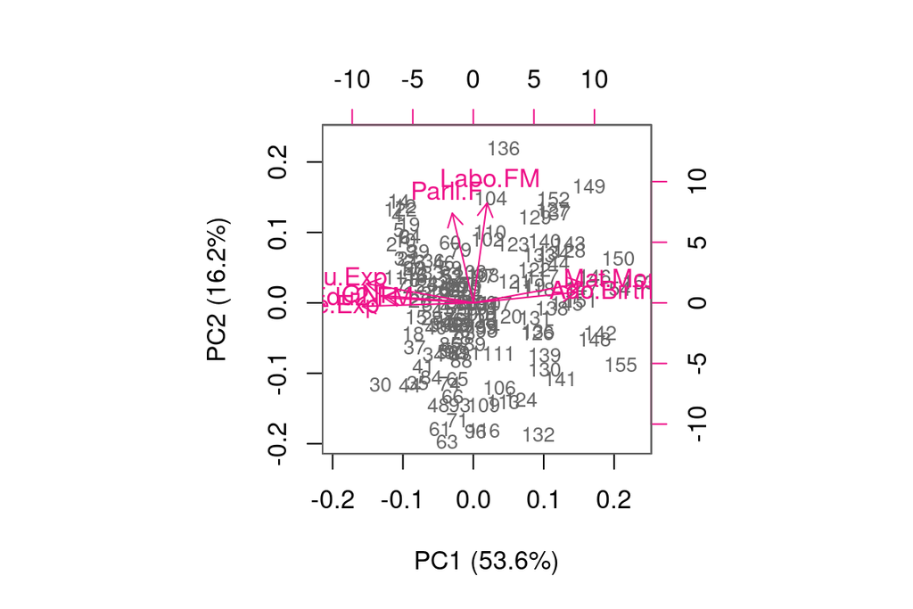

```r
# create object pc_lab to be used as axis labels
pc_lab <- paste0(names(pca_pr), " (", pca_pr, "%)")

# draw a biplot
biplot(pca_human_std, cex = c(0.8, 1), col = c("grey40", "deeppink2"), xlab = pc_lab[1], ylab = pc_lab[2])
```

[figure not shown]

# **Assignment 6: Analysis of longitudinal data**

This week the aim was to study two different datasets with repeated measurements on each subject. Repeated measurements pose problems for the analysis as they are usually correlated rather than independent.

**PART I: Rats**

First dataset to analyze consists of observations 16 rats and their body weight evolution. The rats were divided into three groups that received different diets. The body weight was measured weekly over 9 weeks. The weekly observations are first gathered into long form. A plot showing the weight development of each individual rat is shown below.

```r
library(tidyr); library(dplyr)
library(ggplot2); library(GGally)

# Read the RATS data
RATS <- read.table("https://raw.githubusercontent.com/KimmoVehkalahti/MABS/master/Examples/data/rats.txt",  header = TRUE, sep = '\t')

glimpse(RATS)
```

```
## Rows: 16
## Columns: 13
## $ ID    <int> 1, 2, 3, 4, 5, 6, 7, 8, 9, 10, 11, 12, 13, 14, 15, 16
## $ Group <int> 1, 1, 1, 1, 1, 1, 1, 1, 2, 2, 2, 2, 3, 3, 3, 3
## $ WD1   <int> 240, 225, 245, 260, 255, 260, 275, 245, 410, 405, 445, 555, 470,…
## $ WD8   <int> 250, 230, 250, 255, 260, 265, 275, 255, 415, 420, 445, 560, 465,…
## $ WD15  <int> 255, 230, 250, 255, 255, 270, 260, 260, 425, 430, 450, 565, 475,…
## $ WD22  <int> 260, 232, 255, 265, 270, 275, 270, 268, 428, 440, 452, 580, 485,…
## $ WD29  <int> 262, 240, 262, 265, 270, 275, 273, 270, 438, 448, 455, 590, 487,…
## $ WD36  <int> 258, 240, 265, 268, 273, 277, 274, 265, 443, 460, 455, 597, 493,…
## $ WD43  <int> 266, 243, 267, 270, 274, 278, 276, 265, 442, 458, 451, 595, 493,…
## $ WD44  <int> 266, 244, 267, 272, 273, 278, 271, 267, 446, 464, 450, 595, 504,…
## $ WD50  <int> 265, 238, 264, 274, 276, 284, 282, 273, 456, 475, 462, 612, 507,…
## $ WD57  <int> 272, 247, 268, 273, 278, 279, 281, 274, 468, 484, 466, 618, 518,…
## $ WD64  <int> 278, 245, 269, 275, 280, 281, 284, 278, 478, 496, 472, 628, 525,…
```

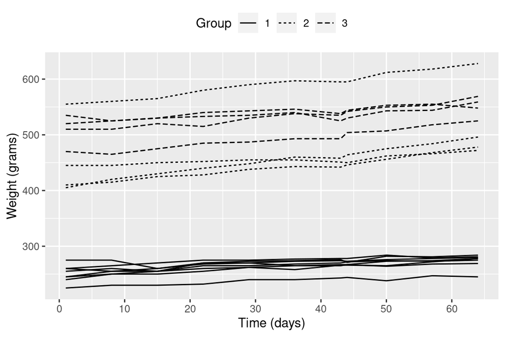

```r
# Factor variables ID and Group
RATS$ID <- factor(RATS$ID)
RATS$Group <- factor(RATS$Group)

# Convert data to long form and extract Time variable as integer
RATSL <- RATS %>%
  gather(key = WD, value = Weight, -ID, -Group) %>%
  mutate(Time = as.integer(substr(WD,3,4)))

ggplot(RATSL, aes(x = Time, y = Weight, group = ID)) +
  geom_line(aes(linetype = Group)) +
  scale_x_continuous(name = "Time (days)", breaks = seq(0, 60, 10)) +
  scale_y_continuous(name = "Weight (grams)") + theme(legend.position = "top")
```

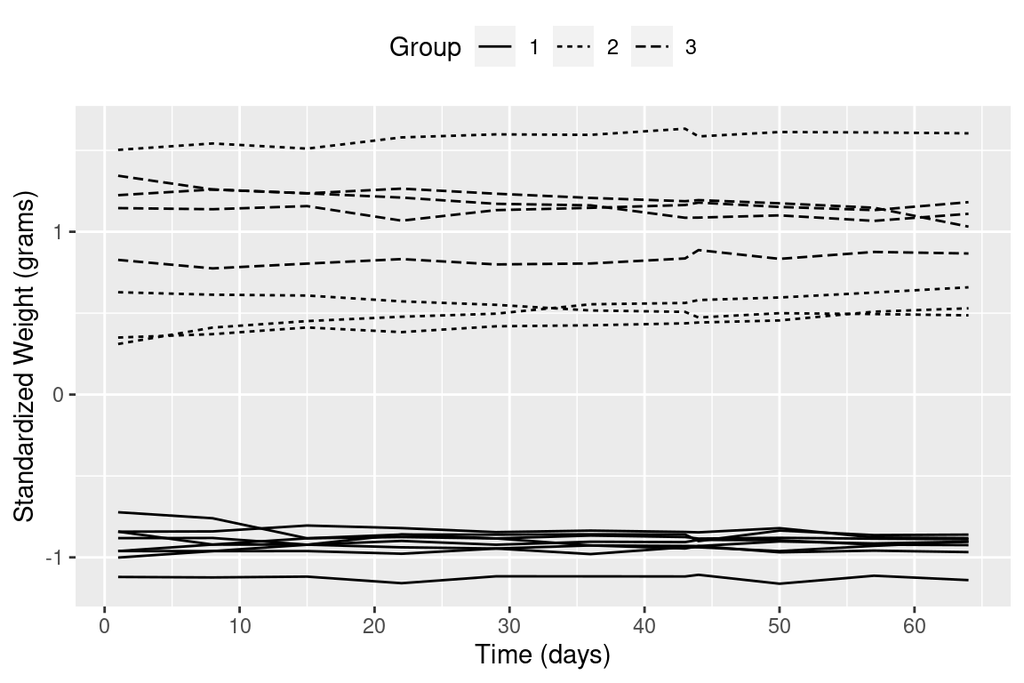

```r
# Standardise the variable Weight
RATSL <- RATSL %>%
  group_by(Time) %>%
  mutate(stdweight = (Weight - mean(Weight))/sd(Weight) ) %>%
  ungroup()

# Plot again with the standardized Weight
ggplot(RATSL, aes(x = Time, y = stdweight, group = ID)) +
  geom_line(aes(linetype = Group)) +
  scale_x_continuous(name = "Time (days)", breaks = seq(0, 60, 10)) +
  scale_y_continuous(name = "Standardized Weight (grams)") + theme(legend.position = "top")
```

The lines representing the weight development of individual rats in the figure above suggest that there may be some differences between the groups. To study this better, a mean of each group is taken and plotted below. (Here I got a bit lost as I was not sure if n was supposed to represent the amount of time steps / measurements like in the DataCamp exercise or number of individuals in a group like in the correction of the exercise. I chose the first option simply because the group sizes were not even: Group 1 has 8 individuals while groups 2 and 3 have four in each.)

```r
# Number of weeks, baseline (week 0) included
n <- 11

# Summary data with mean and standard error of Weight by Group and week
RATSS <- RATSL %>%
  group_by(Group, Time) %>%
  summarise( mean = mean(Weight), se = sd(Weight)/sqrt(n) ) %>%
  ungroup()
```

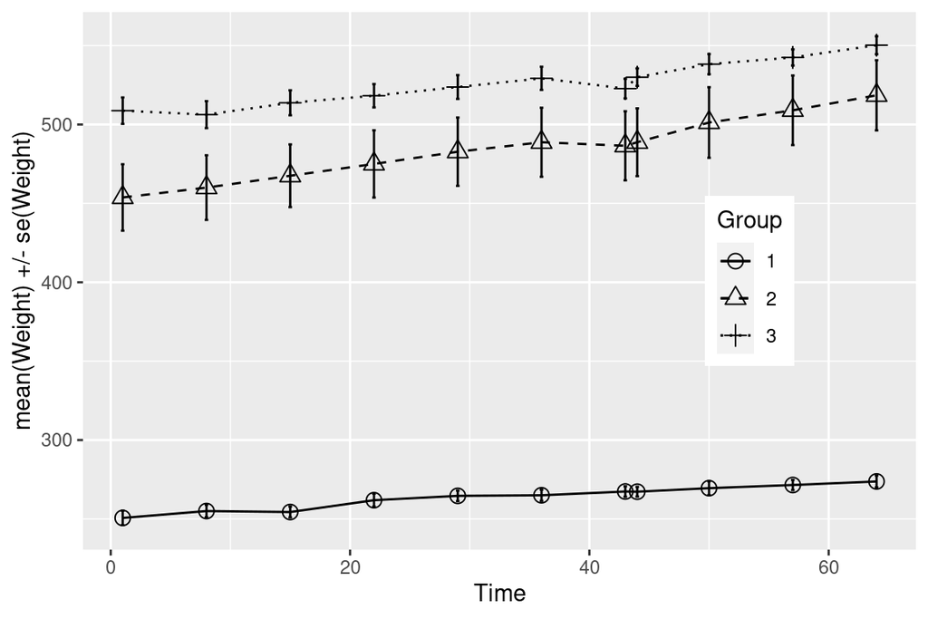

```r
# Plot the mean profiles
ggplot(RATSS, aes(x = Time, y = mean, linetype = Group, shape = Group)) +
  geom_line() + scale_linetype_manual(values = c(1,2,3)) +
  geom_point(size=3) +
  scale_shape_manual(values = c(1,2,3)) +
  geom_errorbar(aes(ymin = mean - se, ymax = mean + se, linetype="1"), width=0.3) +
  theme(legend.position = c(0.8,0.5)) +
  scale_y_continuous(name = "mean(Weight) +/- se(Weight)")
```

From the means above it can be seen that Group has higher standard error than the other two groups. It might be worthwhile to check what is going on there. The distributions are analyzed with boxplots in the figure below.

```r
# Create a summary data by Group and ID with mean as the summary variable (ignoring baseline week 0).
RATSL8S <- RATSL %>%
  filter(Time > 0) %>%
  group_by(Group, ID) %>%
  summarise( mean=mean(Weight) ) %>%
  ungroup()
```

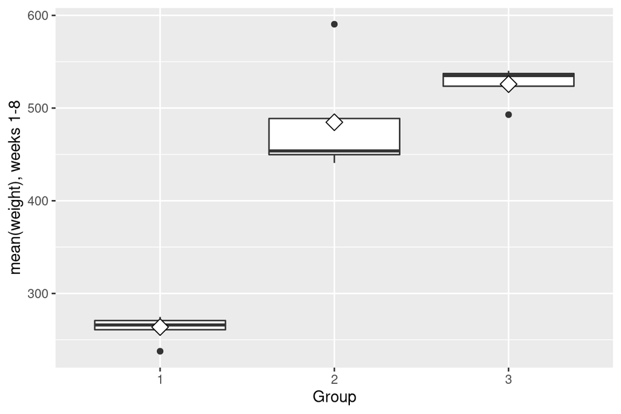

```r
# Draw a boxplot of the mean versus treatment
ggplot(RATSL8S, aes(x = Group, y = mean)) +
  geom_boxplot() +
  stat_summary(fun = "mean", geom = "point", shape=23, size=4, fill = "white") +
  scale_y_continuous(name = "mean(weight), weeks 1-8")
```

The boxplots reveal that all the groups have outliers, but in Group the outlier is causing quite strong skewedness. Therefore it should be removed and filtered out.

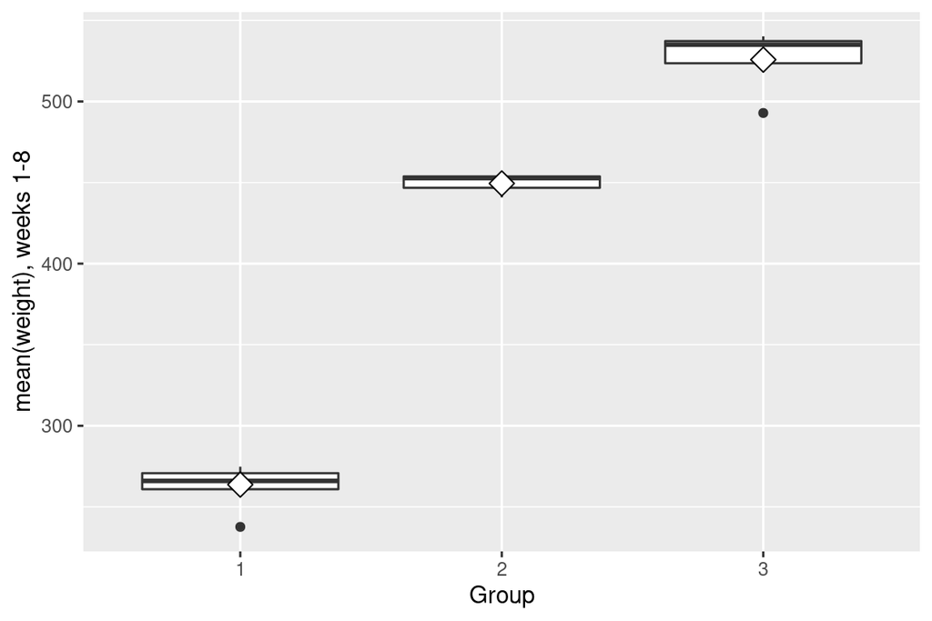

```r
# Create a new data by filtering the outlier and adjust the ggplot code the draw the plot again with the new data
RATSL8S1 <- RATSL8S %>%
  filter(mean < 550)

ggplot(RATSL8S1, aes(x = Group, y = mean)) +
  geom_boxplot() +
  stat_summary(fun = "mean", geom = "point", shape=23, size=4, fill = "white") +
  scale_y_continuous(name = "mean(weight), weeks 1-8")
```

New boxplots without the outlier (above) seem better. Group 3 is still a bit skewed, but I can live with this and continue to perform t-test. As t-tests are used to define if the significance between two samples are significantly different and here three groups are studied, I compared groups 1 and 2, groups 1 and 3 and groups 2 and 3 together. As seen from the results below, the p-values are low for all comparisons and therefore it seems that the diets really influence the weight development.

```r
# Perform t-test on groups 1 & 2
t.test(mean[1:11] ~ Group[1:11], data = RATSL8S1, var.equal = TRUE)
```

```
##
##  Two Sample t-test
##
## data:  mean[1:11] by Group[1:11]
## t = -24.838, df = 9, p-value = 1.334e-09
## alternative hypothesis: true difference in means between group 1 and group 2 is not equal to 0
## 95 percent confidence interval:
##  -202.6549 -168.8224
## sample estimates:
## mean in group 1 mean in group 2
##        263.7159        449.4545
```

```r
# Perform t-test on groups 1 & 3
t.test(mean[c(1:8,12:15)] ~ Group[c(1:8,12:15)], data = RATSL8S1, var.equal = TRUE)
```

```
##
##  Two Sample t-test
##
## data:  mean[c(1:8, 12:15)] by Group[c(1:8, 12:15)]
## t = -27.361, df = 10, p-value = 9.848e-11
## alternative hypothesis: true difference in means between group 1 and group 3 is not equal to 0
## 95 percent confidence interval:
##  -283.4218 -240.7373
## sample estimates:
## mean in group 1 mean in group 3
##        263.7159        525.7955
```

```r
# Perform t-test on groups 2 & 3
t.test(mean[9:15] ~ Group[9:15], data = RATSL8S1, var.equal = TRUE)
```

```
##
##  Two Sample t-test
##
## data:  mean[9:15] by Group[9:15]
## t = -5.6287, df = 5, p-value = 0.002452
## alternative hypothesis: true difference in means between group 2 and group 3 is not equal to 0
## 95 percent confidence interval:
##  -111.20490  -41.47691
## sample estimates:
## mean in group 2 mean in group 3
##        449.4545        525.7955
```

I also use the baseline as a separate variable to see how it relates to the different diets between different groups. From the results shown below, it is seen that the baseline correlates significantly with the individuals response to the diet. However, differences between the groups are not significant (Pr(>F) > 0.05).

```r
# Add the baseline from the original data as a new variable to the summary data
RATSL8S2 <- RATSL8S %>%
  mutate(baseline = RATS$WD1)

# Fit the linear model with the mean as the response
fit <- lm(mean ~ baseline + Group, data = RATSL8S2)

# Compute the analysis of variance table for the fitted model with anova()
anova(fit)
```

```
## Analysis of Variance Table
##
## Response: mean
##           Df Sum Sq Mean Sq   F value    Pr(>F)
## baseline   1 252125  252125 2237.0655 5.217e-15 ***
## Group      2    726     363    3.2219   0.07586 .
## Residuals 12   1352     113
## ---
## Signif. codes:  0 '***' 0.001 '**' 0.01 '*' 0.05 '.' 0.1 ' ' 1
```

**PART II: Psychiatric patients**

The second dataset consists of observations of 40 individuals suspected of having schizophrenia. The individuals are randomly divided into two groups receiving different treatments. The effect of the treatment is measured with brief psychiatric rating scale (bprs) and the individuals are followed for eight weeks.

This dataset is as well transformed to the long form before analysis. The summary of the data is given in the plot below, which shows the influence of the treatment of each individual with group 1 on the left and group 2 on the right panel.

```r
BPRS <- read.table("https://raw.githubusercontent.com/KimmoVehkalahti/MABS/master/Examples/data/BPRS.txt", sep  =" ", header = T)

# Factor treatment & subject
BPRS$treatment <- factor(BPRS$treatment)
BPRS$subject <- factor(BPRS$subject)

# Convert to long form
BPRSL <- BPRS %>% gather(key = weeks, value = bprs, -treatment, -subject)

# Extract the week number
BPRSL <-  BPRSL %>% mutate(week = as.integer(substr(weeks,5,5)))

# Take a glimpse at the BPRSL data
glimpse(BPRSL)
```

```
## Rows: 360
## Columns: 5
## $ treatment <fct> 1, 1, 1, 1, 1, 1, 1, 1, 1, 1, 1, 1, 1, 1, 1, 1, 1, 1, 1, 1, …
## $ subject   <fct> 1, 2, 3, 4, 5, 6, 7, 8, 9, 10, 11, 12, 13, 14, 15, 16, 17, 1…
## $ weeks     <chr> "week0", "week0", "week0", "week0", "week0", "week0", "week0…
## $ bprs      <int> 42, 58, 54, 55, 72, 48, 71, 30, 41, 57, 30, 55, 36, 38, 66, …
## $ week      <int> 0, 0, 0, 0, 0, 0, 0, 0, 0, 0, 0, 0, 0, 0, 0, 0, 0, 0, 0, 0, …
```

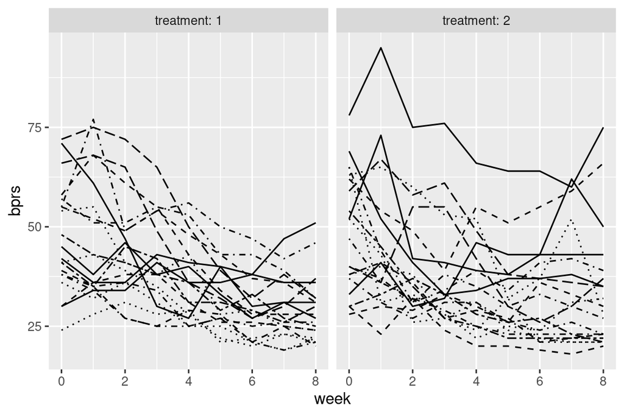

```r
# Draw the plot
ggplot(BPRSL, aes(x = week, y = bprs, linetype = subject)) +
  geom_line() +
  scale_linetype_manual(values = rep(1:10, times=4)) +
  facet_grid(. ~ treatment, labeller = label_both) +
  theme(legend.position = "none") +
  scale_y_continuous(limits = c(min(BPRSL$bprs), max(BPRSL$bprs)))
```

As a first step, the correlation of the repeated measurements is ignored and a simple linear regression model is fitted to the data with BPRS as target variable and week and treatment as explanatory variables.

```r
# create a regression model BPRS_reg
BPRS_reg <- lm(bprs ~ week + treatment, data = BPRSL)

# print out a summary of the model
summary(BPRS_reg)
```

```
##
## Call:
## lm(formula = bprs ~ week + treatment, data = BPRSL)
##
## Residuals:
##     Min      1Q  Median      3Q     Max
## -22.454  -8.965  -3.196   7.002  50.244
##
## Coefficients:
##             Estimate Std. Error t value Pr(>|t|)
## (Intercept)  46.4539     1.3670  33.982   <2e-16 ***
## week         -2.2704     0.2524  -8.995   <2e-16 ***
## treatment2    0.5722     1.3034   0.439    0.661
## ---
## Signif. codes:  0 '***' 0.001 '**' 0.01 '*' 0.05 '.' 0.1 ' ' 1
##
## Residual standard error: 12.37 on 357 degrees of freedom
## Multiple R-squared:  0.1851, Adjusted R-squared:  0.1806
## F-statistic: 40.55 on 2 and 357 DF,  p-value: < 2.2e-16
```

Because the assumption of independence is most likely misleading, it is better to fit a random intercept model to the data. Week and treatment are the explanatory variables and subject the random effect, which accounts for unmeasured individual qualities that can influence the results.

Unfortunately there were again some dependencies not working in my version of R (on Ubuntu) and to be able to use lme4 library I would have had to downgrade R to an older version. I was too short on time to go through that trouble, so I just tried to run the pieces of code on DataCamp and copy-paste the results from there. R-markdown managed to mess up the formatting of the copy-pasted summaries, so I was not able to do any sensible analysis out of them after all, so this analysis consists of the steps taken in order to perform the analysis.

```r
# access library lme4
#library(lme4)

# Create a random intercept model
#BPRS_ref <- lmer(bprs ~ week + treatment + (1 | subject), data = BPRSL, REML = FALSE)

# Print the summary of the model
#summary(BPRS_ref)
```

```r
#Linear mixed model fit by maximum likelihood \['lmerMod'\] Formula: bprs
#\~ week + treatment + (1 \| subject) Data: BPRSL

#     AIC      BIC   logLik deviance df.resid

#2748.7 2768.1 -1369.4 2738.7 355

#Scaled residuals: Min 1Q Median 3Q Max -3.0481 -0.6749 -0.1361 0.4813
#3.4855

#Random effects: Groups Name Variance Std.Dev. subject (Intercept) 47.41
#6.885\
#Residual 104.21 10.208\
#Number of obs: 360, groups: subject, 20

#Fixed effects: Estimate Std. Error t value (Intercept) 46.4539 1.9090
#24.334 week -2.2704 0.2084 -10.896 treatment2 0.5722 1.0761 0.532

#Correlation of Fixed Effects: (Intr) week\
#week -0.437\
#treatment2 -0.282 0.000
```

The random intercept model does not take into account the effect of time, which mean it constrains the variance of each repeated measurement to be the same and the correlation of each pair of measurements to be equal. This is an unlikely situation and therefore, in order to include also the effect of time on the results, I add random slope to the random intercept model.

```r
# create a random intercept and random slope model
#BPRS_ref1 <- lmer(bprs ~ week + treatment + (week | subject), data = BPRSL, REML = FALSE)

# print a summary of the model
#summary(BPRS_ref1)
```

Next the analysis of variance is performed to compare the two tests.

```r
# perform an ANOVA test on the two models
#anova(BPRS_ref1, BPRS_ref)

#Data: BPRSL Models: BPRS_ref: bprs \~ week + treatment + (1 \| subject)
#BPRS_ref1: bprs \~ week + treatment + (week \| subject) Df AIC BIC
#logLik deviance Chisq Chi Df Pr(>Chisq)\
#BPRS_ref 5 2748.7 2768.1 -1369.4 2738.7\
#BPRS_ref1 7 2745.4 2772.6 -1365.7 2731.4 7.2721 2 0.02636 *---
#Signif.codes: 0 '***' 0.001 '**' 0.01 '\*' 0.05 '.' 0.1 ' ' 1
```

Next a random intercept and random slope model with the interaction week x treatment is created. Then the model is tested against the random intercept and random slope model without this interaction.

```r
# create a random intercept and random slope model with the interaction
#BPRS_ref2 <- lmer(bprs ~ week * treatment + (week | subject), data = BPRSL, REML = FALSE)

# print a summary of the model
#summary(BPRS_ref2)
```

```r
# perform an ANOVA test on the two models
#anova(BPRS_ref2, BPRS_ref1)

#Data: BPRSL Models: BPRS_ref1: bprs \~ week + treatment + (week \|
#subject) BPRS_ref2: bprs \~ week \* treatment + (week \| subject) Df AIC
#BIC logLik deviance Chisq Chi Df Pr(>Chisq)\
#BPRS_ref1 7 2745.4 2772.6 -1365.7 2731.4\
#BPRS_ref2 8 2744.3 2775.4 -1364.1 2728.3 3.1712 1 0.07495 . ---
#Signif.codes: 0 '***' 0.001 '**' 0.01 '*' 0.05 '.' 0.1 ' ' 1
```

[figure not shown]

```r
# Plot the fitted data
#ggplot(BPRSL, aes(x = week, y = Fitted, linetype = subject)) +
#  geom_line(aes(linetype = subject)) +
 # scale_linetype_manual(values = rep(1:10, times=4)) +
 # facet_grid(. ~ treatment, labeller = label_both) +
 # theme(legend.position = "None") +
 # scale_y_continuous(limits = c(min(BPRSL$bprs), max(BPRSL$bprs)))
```

(more chapters to be added similarly as we proceed with the course!)